# Detección GBM - analisis de los factores de riesgo

```r
library(jsonlite)
library(corrplot)
library(Amelia)
library(caret)
library(e1071)
library(survival)
library(ranger)
library(mice)
library(RColorBrewer)
library(gridExtra)
library(ggplot2)
library(ggpmisc)
library(data.table)
library(dplyr)
library(tidyr)
library(purrr)
```

Este script muestra los pasos seguidos para el análisis de los factores de riesgo que pueden llevar al desarrollo de un glioblastoma multiforme (GBM) y no sobrevivir. Además, se incluyen también las características extraidas de los escáneres MRI de los pacientes.

```r
load(file = 'dataset_images_12month.Rda')

dataset_images_12month$cause_of_death_at_12months_follow_up <- as.factor(dataset_images_12month$cause_of_death_at_12months_follow_up)
dataset_images_12month$vital_status_at_12months_follow_up <- as.factor(dataset_images_12month$vital_status_at_12months_follow_up)
dataset_images_12month$gender <- as.factor(dataset_images_12month$gender)
```

# Cargar características extraidas de las imágenes

Hay que cargar el fichero CSV creado a partir de las características extraidas de las imágenes y unirlo con el dataset de los factores de riesgo usando el ID de los pacientes. Además, como no se disponen imágenes de todos los pacientes, se eliminarán aquellos pacientes de los que solo se dispongan metadatos. Se cambia la forma en la que estaban representados los NA en el CSV de las características para que coincida con el dataset de los factores de riesgo.

```r
filename <- "features/features_07_06.csv"
dataset_features <- read.csv(filename, header=TRUE)
dataset_features[dataset_features == "NaN"] <- NA
```

# Ajustar el nuevo dataset

Hay que comprobar si hace falta ajustar el tipo de dato de ciertas variables.

```r
sapply(dataset_features, class)
```

```
                 case_id           tumor_mri_type             tumor_volume             tumor_dist_x             tumor_dist_y
             "character"              "character"                "numeric"                "numeric"                "numeric"
       tumor_compactness                 tumor_uf                tumor_std                tumor_var           tumor_skewness
               "numeric"                "numeric"                "numeric"                "numeric"                "numeric"
               tumor_kur                tumor_ent         tumor_smoothness         tumor_uniformity      tumor_glcm_contrast
               "numeric"                "numeric"                "numeric"                "numeric"                "numeric"
tumor_glcm_dissimilarity   tumor_glcm_homogeneity        tumor_glcm_energy   tumor_glcm_correlation           tumor_glcm_ASM
               "numeric"                "numeric"                "numeric"                "numeric"                "numeric"
              tumor_Hu_1               tumor_Hu_2               tumor_Hu_3               tumor_Hu_4               tumor_Hu_5
               "numeric"                "numeric"                "numeric"                "numeric"                "numeric"
              tumor_Hu_6               tumor_Hu_7           edema_mri_type             edema_volume             edema_dist_x
               "numeric"                "numeric"              "character"                "numeric"                "numeric"
            edema_dist_y        edema_compactness                 edema_uf                edema_std                edema_var
               "numeric"                "numeric"                "numeric"                "numeric"                "numeric"
          edema_skewness                edema_kur                edema_ent         edema_smoothness         edema_uniformity
               "numeric"                "numeric"                "numeric"                "numeric"                "numeric"
     edema_glcm_contrast edema_glcm_dissimilarity   edema_glcm_homogeneity        edema_glcm_energy   edema_glcm_correlation
               "numeric"                "numeric"                "numeric"                "numeric"                "numeric"
          edema_glcm_ASM               edema_Hu_1               edema_Hu_2               edema_Hu_3               edema_Hu_4
               "numeric"                "numeric"                "numeric"                "numeric"                "numeric"
              edema_Hu_5               edema_Hu_6               edema_Hu_7
               "numeric"                "numeric"                "numeric"
```

```r
dataset_features$case_id <- as.factor(dataset_features$case_id)
dataset_features$tumor_mri_type <- as.factor(dataset_features$tumor_mri_type)
dataset_features$edema_mri_type <- as.factor(dataset_features$edema_mri_type)
```

## EXPLORATORY DATA ANALYSIS

- Debido a que algunos de los NA presentes en el dataset de las características se dan en casos en los que no es posible calcular esas características porque no se ha encontrado ningún tumor o edema por ejemplo, se sustituirán estos valores por un valor extremo como puede ser “-99999”. Así, se ve que estas entradas son especiales y se podrán tener en cuenta. Esto se da cuando el volumen del edema o del tumor es 0 y tiene algún NA.
- Aun así, hay una excepción para los casos anteriores. Los casos en los que todos los valores son NA (incluyendo el volumen del tumor o del edema) deberán ser imputados ya que no significa que no se haya encontrado ningún tumor, sino que no se dispone de un escáner para analizarlo. También hay algún caso donde se ha detectado una anomalía pero existe al menos un NA. Estos NA no se cambiarán para que sean imputados después.

```r
tumor_volume_0_DF <- dataset_features[ which( dataset_features$tumor_volume == 0), ]
edema_volume_0_DF <- dataset_features[ which( dataset_features$edema_volume == 0), ]
dataset_na <- dataset_features[ which( is.na(dataset_features$tumor_mri_type) | is.na(dataset_features$edema_mri_type)) , ]
dataset_features <- dataset_features[ which( dataset_features$tumor_volume != 0 & dataset_features$edema_volume != 0) , ]

# Fill tumor values
index <- tumor_volume_0_DF$tumor_volume == 0
index[is.na(index)] <- FALSE
tumor_volume_0_DF[which(rowSums(is.na(tumor_volume_0_DF[index, c(4:27)])) > 10), c(4:27)] <- -99999

# Fill edema values
index <- edema_volume_0_DF$edema_volume == 0
index[is.na(index)] <- FALSE
edema_volume_0_DF[which(rowSums(is.na(edema_volume_0_DF[index, c(30:53)])) > 10), c(30:53)] <- -99999

dataset_features <- rbind(dataset_features, tumor_volume_0_DF, edema_volume_0_DF, dataset_na)

dataset_images_merge <- merge(dataset_images_12month, dataset_features, by="case_id", all=TRUE)
dataset_images_merge <- dataset_images_merge[!is.na(dataset_images_merge$tumor_volume),]
```

En este dataset se diferencian tres variables de clase distintas: cause_of_death_at_12months_follow_up o la causa de la muerte si es que la hay a los 12 meses, vital_status_at_12months_follow_up o el estado del paciente (vivo/muerto) a los 12 meses y life_expectancy o los dias que han pasado desde el diagnóstico del GBM hasta su muerte si es que la hay.

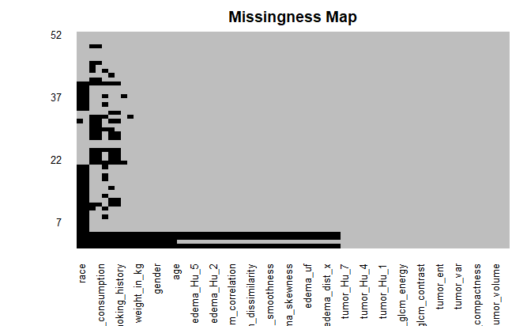

```r
set.seed(173)
dataset_images_merge_red <- dataset_images_merge

# Missing values
missmap(dataset_images_merge_red, col=c("black", "grey"), legend=FALSE)
```

```r
cause_of_death_index <- which(names(dataset_images_merge_red) == 'cause_of_death_at_12months_follow_up', arr.ind = TRUE)
vital_status_index <- which(names(dataset_images_merge_red) == 'vital_status_at_12months_follow_up', arr.ind = TRUE)
life_expectancy_index <- which(names(dataset_images_merge_red) == 'life_expectancy', arr.ind = TRUE)

dataset_images_merge_red[c(cause_of_death_index, vital_status_index, life_expectancy_index)] <- NULL

# Elminar las entradas con más del 30% de las variables con NA
# Tamaño del dataset antes de eliminar entradas
dim(dataset_images_merge_red)
```

```
[1] 52 66
```

```r
dataset_images_merge_red <- dataset_images_merge_red[which(rowMeans(!is.na(dataset_images_merge_red)) > 0.7), ]
dataset_images_merge <- dataset_images_merge[which(rowMeans(!is.na(dataset_images_merge[, -c(cause_of_death_index, vital_status_index, life_expectancy_index)])) > 0.7), ]

# Eliminar variables con más del 40% de los valores con NA
dataset_images_merge_red <- cbind(dataset_images_merge_red[, which(colMeans(!is.na(dataset_images_merge_red[,])) > 0.6)], dataset_images_merge[,c(cause_of_death_index, vital_status_index, life_expectancy_index)])

cause_of_death_index <- which(names(dataset_images_merge_red) == 'cause_of_death_at_12months_follow_up', arr.ind = TRUE)
vital_status_index <- which(names(dataset_images_merge_red) == 'vital_status_at_12months_follow_up', arr.ind = TRUE)
life_expectancy_index <- which(names(dataset_images_merge_red) == 'life_expectancy', arr.ind = TRUE)

numeric_var_indexes_all <- c(which(sapply(dataset_images_merge_red, class) == 'numeric', arr.ind = TRUE), which(sapply(dataset_images_merge_red, class) == 'integer', arr.ind = TRUE))
numeric_var_indexes <- numeric_var_indexes_all[-which(numeric_var_indexes_all ==  life_expectancy_index, arr.ind = TRUE)]

non_numeric_var_indexes_all <- which(sapply(dataset_images_merge_red, class) == 'factor', arr.ind = TRUE)
non_numeric_var_indexes <- non_numeric_var_indexes_all[-which(non_numeric_var_indexes_all ==  cause_of_death_index, arr.ind = TRUE)]
non_numeric_var_indexes <- non_numeric_var_indexes[-which(non_numeric_var_indexes ==  vital_status_index, arr.ind = TRUE)]

# Tamaño del dataset tras eliminar entradas
dim(dataset_images_merge_red)
```

```
[1] 49 67
```

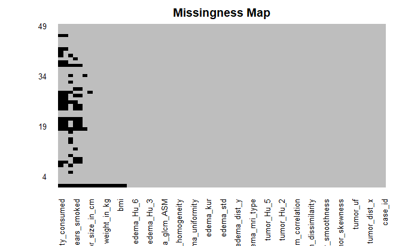

```r
missmap(dataset_images_merge_red, col=c("black", "grey"), legend=FALSE)

# Histogramas de las variables numéricas
par(mfrow=c(1, 4))
```

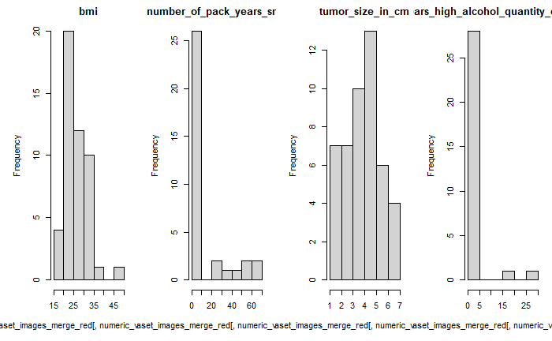

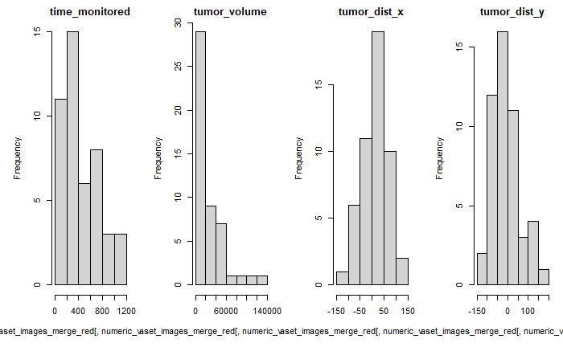

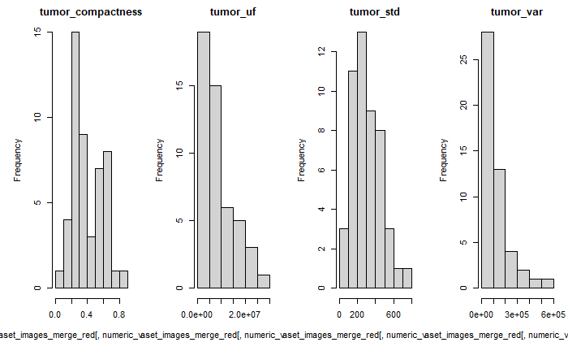

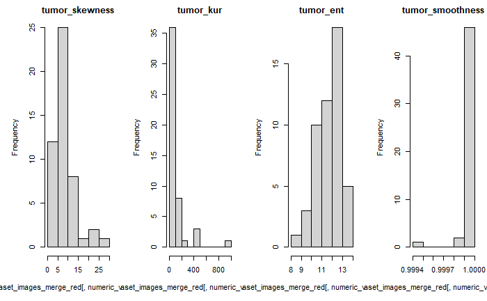

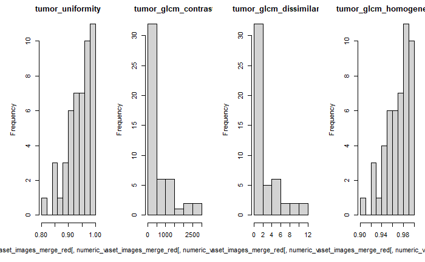

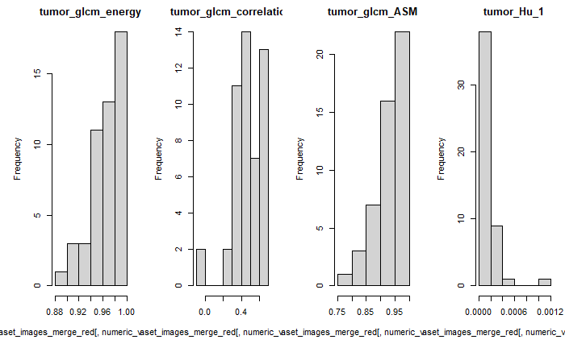

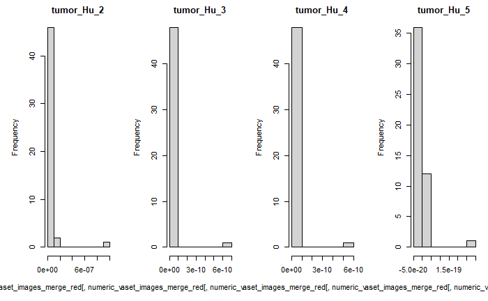

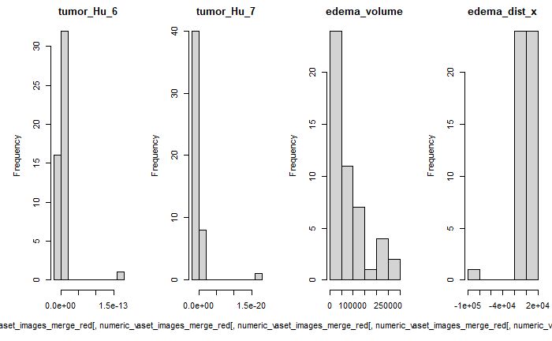

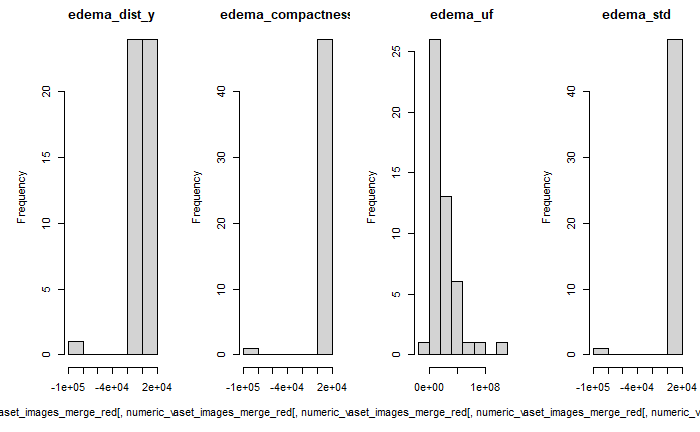

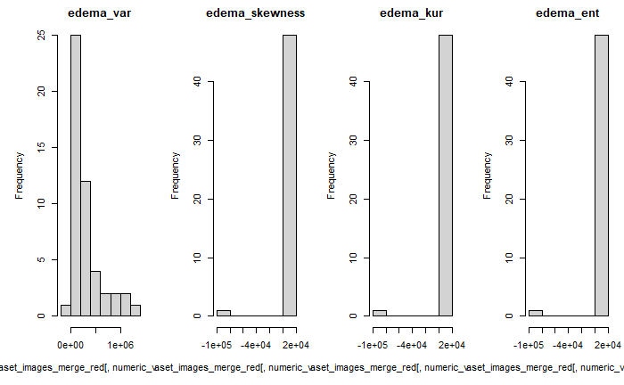

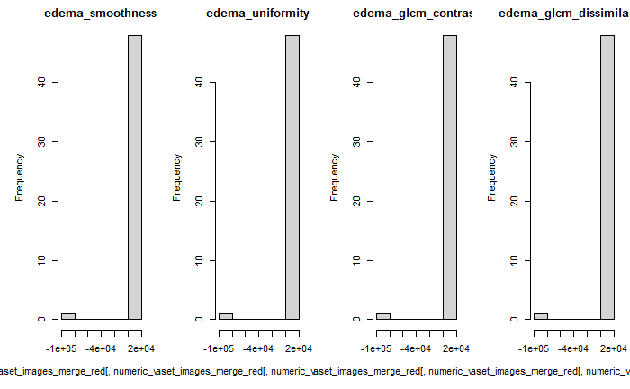

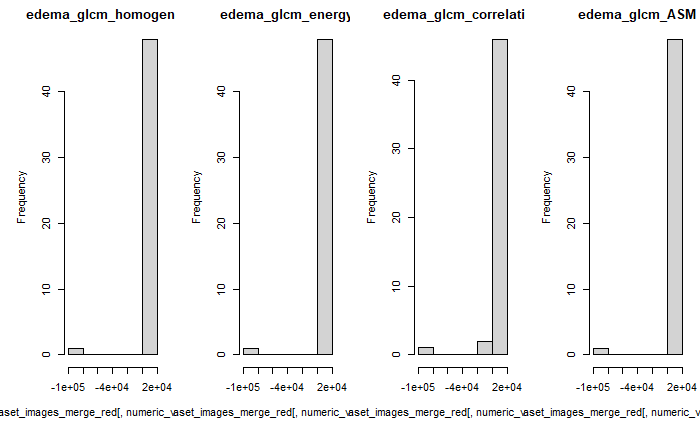

[2 more figures not shown]

```r
for(i in 1:length(numeric_var_indexes)) {
    hist(dataset_images_merge_red[,numeric_var_indexes[i]], main=names(dataset_images_merge_red)[numeric_var_indexes[i]])
}
```